# P5：从安然公司邮件中发现欺诈证据

# 项目综述：

此项目的目标是：通过公开的安然财务和邮件数据，找出有欺诈嫌疑的安然雇员。

机器学习对于实现此目标的帮助：通过机器学习可以构建一个识别嫌疑人的算法，来达到从数据中找出嫌疑人的目的。

# 理解数据集和问题：

# 数据探索：

1.数据点总数：

```python
import pickle
with open("final_project/final_project_dataset.pkl","rb") as data_file:
    data_dict = pickle.load(data_file)
print(len(data_dict))
```

```
146
```

2.类之间的分配（POI/非 POI）：

```python
poi = 0
none_poi = 0
for name in data_dict:
    if data_dict[name]['poi']==1:
        poi = poi +1
    elif data_dict[name]['poi']==0:
        none_poi = none_poi+1
print('poi:',poi)
print('none_poi:',none_poi)
```

```
poi: 18
none_poi: 128
```

1.从POI和非POI的人数比例可以看出：安然数据集很不平衡, 也就说明accuracy并不是很好的评估指标，选择precision和recall更好一些。

理由：因为accuracy是对POI和非POI预测准确率的整体评估，而由于POI的数量很少，这个评估指标会被非POI的准确率主导，不容易看出对POI的识别率如何，因此我们应该采用更加适合的指标来衡量机器学习的性能，也就是precision和recall。precision和recall都可以分别对POI和非POI的识别情况进行评估，效果更好。本次评估我们主要关心机器学习模型对数据集中POI的识别情况。

2.在交叉验证的时候，因为数据的不平衡性，我们会选用Stratified Shuffle Split的方式将数据分为验证集和测试集：

理由：使用Stratified Shuffle Split随机分层抽样交叉验证的好处是，在每次抽样的时候，训练集和测试集都可以分配到相同比例的POI和非POI，不会因为POI数量过少，而导致测试集分配不到POI的情况发生，影响评估效果。

3.由于安然数据样本比较少，因此我们可以使用GridSearchCV来进行参数调整，相反如果较大的数据则会花费较长的时间，可以考虑使用RandomizedSearchCV.

3.使用的特征数量:

数据集中的全部特征：

```python
all_features_list = []
for name in data_dict:
    all_features_list = list(data_dict[name].keys())
    break
all_features_list.remove('poi')
print('all_features_list:','\n',all_features_list,'\n')
print('len(all_features_list):',len(all_features_list))
```

[output not shown]

我使用的特征列表：

```python
features_list = ['salary',
                'total_stock_value','total_payments','long_term_incentive',
                'exercised_stock_options','deferred_income','bonus']
```

```python
print(len(features_list))
```

```
7
```

4.是否有哪些样本或特征有很多缺失值：

概览数据：

```python
import pandas as pd
a = pd.DataFrame(data_dict)
a.head()
```

|  | ALLEN PHILLIP K | BADUM JAMES P | BANNANTINE JAMES M | BAXTER JOHN C | BAY FRANKLIN R | BAZELIDES PHILIP J | BECK SALLY W | BELDEN TIMOTHY N | BELFER ROBERT | BERBERIAN DAVID | ... | WASAFF GEORGE | WESTFAHL RICHARD K | WHALEY DAVID A | WHALLEY LAWRENCE G | WHITE JR THOMAS E | WINOKUR JR. HERBERT S | WODRASKA JOHN | WROBEL BRUCE | YEAGER F SCOTT | YEAP SOON |
| --- | --- | --- | --- | --- | --- | --- | --- | --- | --- | --- | --- | --- | --- | --- | --- | --- | --- | --- | --- | --- | --- |
| bonus | 4175000 | NaN | NaN | 1200000 | 400000 | NaN | 700000 | 5249999 | NaN | NaN | ... | 325000 | NaN | NaN | 3000000 | 450000 | NaN | NaN | NaN | NaN | NaN |
| deferral_payments | 2869717 | 178980 | NaN | 1295738 | 260455 | 684694 | NaN | 2144013 | -102500 | NaN | ... | 831299 | NaN | NaN | NaN | NaN | NaN | NaN | NaN | NaN | NaN |
| deferred_income | -3081055 | NaN | -5104 | -1386055 | -201641 | NaN | NaN | -2334434 | NaN | NaN | ... | -583325 | -10800 | NaN | NaN | NaN | -25000 | NaN | NaN | NaN | NaN |
| director_fees | NaN | NaN | NaN | NaN | NaN | NaN | NaN | NaN | 3285 | NaN | ... | NaN | NaN | NaN | NaN | NaN | 108579 | NaN | NaN | NaN | NaN |
| email_address | phillip.allen@enron.com | NaN | james.bannantine@enron.com | NaN | frank.bay@enron.com | NaN | sally.beck@enron.com | tim.belden@enron.com | NaN | david.berberian@enron.com | ... | george.wasaff@enron.com | dick.westfahl@enron.com | NaN | greg.whalley@enron.com | thomas.white@enron.com | NaN | john.wodraska@enron.com | NaN | scott.yeager@enron.com | NaN |

5 rows × 146 columns

把字典中的'NaN'换成None，然后把DataFrame转化成布尔值：

```python
for name in data_dict:
    for feature in data_dict[name]:
        if data_dict[name][feature]=='NaN':
            data_dict[name][feature]=None
b = pd.DataFrame(data_dict)
c =b.isnull()
c.head()
```

|  | ALLEN PHILLIP K | BADUM JAMES P | BANNANTINE JAMES M | BAXTER JOHN C | BAY FRANKLIN R | BAZELIDES PHILIP J | BECK SALLY W | BELDEN TIMOTHY N | BELFER ROBERT | BERBERIAN DAVID | ... | WASAFF GEORGE | WESTFAHL RICHARD K | WHALEY DAVID A | WHALLEY LAWRENCE G | WHITE JR THOMAS E | WINOKUR JR. HERBERT S | WODRASKA JOHN | WROBEL BRUCE | YEAGER F SCOTT | YEAP SOON |
| --- | --- | --- | --- | --- | --- | --- | --- | --- | --- | --- | --- | --- | --- | --- | --- | --- | --- | --- | --- | --- | --- |
| bonus | False | True | True | False | False | True | False | False | True | True | ... | False | True | True | False | False | True | True | True | True | True |
| deferral_payments | False | False | True | False | False | False | True | False | False | True | ... | False | True | True | True | True | True | True | True | True | True |
| deferred_income | False | True | False | False | False | True | True | False | True | True | ... | False | False | True | True | True | False | True | True | True | True |
| director_fees | True | True | True | True | True | True | True | True | False | True | ... | True | True | True | True | True | False | True | True | True | True |
| email_address | False | True | False | True | False | True | False | False | True | False | ... | False | False | True | False | False | True | False | True | False | True |

5 rows × 146 columns

统计每个特征的样本缺失值数量：

样本缺失值超过100的特征不在最终算法中使用：director_fees、loan_advances、restricted_stock_deferred、deferral_payments，缺失值均超过100.

```python
f = c.iloc[:].sum(axis =1)
f
```

```
bonus                         64
deferral_payments            107
deferred_income               97
director_fees                129
email_address                 35
exercised_stock_options       44
expenses                      51
from_messages                 60
from_poi_to_this_person       60
from_this_person_to_poi       60
loan_advances                142
long_term_incentive           80
other                         53
poi                            0
restricted_stock              36
restricted_stock_deferred    128
salary                        51
shared_receipt_with_poi       60
to_messages                   60
total_payments                21
total_stock_value             20
dtype: int64
```

```python
f = sorted(f,reverse = True)
print(f)
```

```
[142, 129, 128, 107, 97, 80, 64, 60, 60, 60, 60, 60, 53, 51, 51, 44, 36, 35, 21, 20, 0]
```

统计每个样本的特征缺失值数量：删除特征缺失值数量排名第一的样本。

```python
count = []
for name in data_dict:
    count.append((name,c[name].sum()))
count_sort = sorted(count,reverse =True,key = lambda x : x[1])
print(count_sort[:1])
cs = count_sort[:1]
cs_list = [i[0]for i in cs]
print(cs_list)
```

```
[('LOCKHART EUGENE E', 20)]
['LOCKHART EUGENE E']
```

```python
for name in cs_list:
    data_dict.pop(name)

for name in cs_list:
    try:
        print(data_dict[name])
    except:
        print('This item has been delete')
```

```
This item has been delete
```

# 异常值调查：

```python
#!/usr/bin/python

import pickle
import sys
import matplotlib.pyplot as plt
sys.path.append("outliers/")
sys.path.append("final_project/")
from feature_format import featureFormat, targetFeatureSplit
for name in data_dict:
    for feature in data_dict[name]:
        if data_dict[name][feature]==None:
            data_dict[name][feature]='NaN'
features_list = ['salary',
                'total_stock_value','total_payments','long_term_incentive',
                'exercised_stock_options','deferred_income','deferral_payments','bonus']

data = featureFormat(data_dict, features_list)
pd_data = pd.DataFrame(data,columns = features_list)
pd_data.head()
```

|  | salary | total_stock_value | total_payments | long_term_incentive | exercised_stock_options | deferred_income | deferral_payments | bonus |
| --- | --- | --- | --- | --- | --- | --- | --- | --- |
| 0 | 365788.0 | 585062.0 | 1061827.0 | 0.0 | 0.0 | 0.0 | 0.0 | 600000.0 |
| 1 | 267102.0 | 10623258.0 | 5634343.0 | 1586055.0 | 6680544.0 | -1386055.0 | 1295738.0 | 1200000.0 |
| 2 | 170941.0 | 6678735.0 | 211725.0 | 0.0 | 4890344.0 | -400729.0 | 0.0 | 350000.0 |
| 3 | 0.0 | 1038185.0 | 0.0 | 0.0 | 651850.0 | 0.0 | 0.0 | 0.0 |
| 4 | 243293.0 | 6391065.0 | 288682.0 | 1617011.0 | 5538001.0 | -3117011.0 | 0.0 | 1500000.0 |

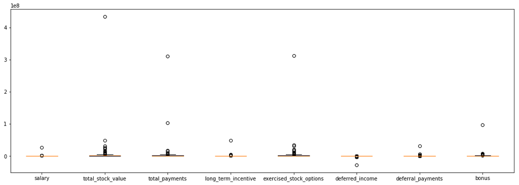

```python
import seaborn as sns
a = []
for feature in features_list:
    a.append(pd_data[feature])
plt.figure(figsize=(18,6))
plt.boxplot((a),labels =features_list)
plt.show()
```

从图中可以看出几乎每一个特征都有一个异常值，找出这些异常值：

推测：有可能这些特征中的异常值都来自一个比较特别的员工。

```python
num_max = []
for feature in features_list:
    num_max.append(pd_data[feature].max())
print(num_max)
```

```
[26704229.0, 434509511.0, 309886585.0, 48521928.0, 311764000.0, 0.0, 32083396.0, 97343619.0]
```

查看这些异常值对应的人名：

```python
for name in data_dict:
    for feature in features_list:
        if data_dict[name][feature] in num_max:
            print(name)
```

```
TOTAL
TOTAL
TOTAL
TOTAL
TOTAL
TOTAL
TOTAL
```

由查询结果得知：所有特征的异常值所对应的人名都为TOTAL，而TOTAL不是一个人名，是文档编辑时对每个特征值的加总信息，因此需要删除这个异常值。

```python
data_dict.pop('TOTAL')
for name in data_dict:
    if name!='TOTAL':
        continue
    else:
        print('dict still have name TOTAL')
```

到此为止：特征列表中所有'TOTAL'键中包含的异常值都被删除了。

再次从可视化中查看是否所选特征中依然有异常值：

```python
data_2 = featureFormat(data_dict, features_list)
pd_data_2 = pd.DataFrame(data_2,columns = features_list)
```

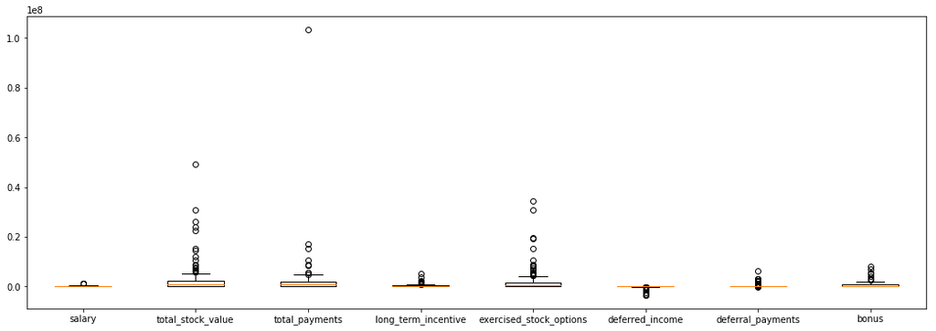

```python
import seaborn as sns
b = []
for feature in features_list:
    b.append(pd_data_2[feature])
plt.figure(figsize=(18,6))
plt.boxplot((b),labels =features_list)
plt.show()
```

从可视化中可以可以看出各个特征中依然有异常值：

因此需要继续找出异常值对应的人名：

```python
num_max_2 = []
for feature in features_list:
    num_max_2.append(pd_data_2[feature].max())
print(num_max_2)
```

```
[1111258.0, 49110078.0, 103559793.0, 5145434.0, 34348384.0, 0.0, 6426990.0, 8000000.0]
```

```python
for name in data_dict:
    for feature in features_list:
        if data_dict[name][feature] in num_max_2:
            print(name)
```

```
LAVORATO JOHN J
LAY KENNETH L
LAY KENNETH L
LAY KENNETH L
SKILLING JEFFREY K
FREVERT MARK A
MARTIN AMANDA K
```

从异常值对应的名字可以看出来，这些人名都是安然公司的一些高管和员工，很有可能是嫌疑人，因此就不再对这些异常值做进一步的删除处理了。

# 优化特征选择/工程：

# 明智地选择特征：

首先剔除掉：email_address这个特征，因为这个特征包含了员工的姓名，而任何人都有自己的姓名，很明显姓名不能作为找出嫌疑人的依据，需要删除。

```python
features_list = ['poi','salary', 'to_messages', 'deferral_payments', 'total_payments', 'exercised_stock_options',\
                 'bonus', 'restricted_stock', 'shared_receipt_with_poi', 'restricted_stock_deferred',\
                 'total_stock_value', 'expenses', 'loan_advances', 'from_messages', 'other', 'from_this_person_to_poi', \
                 'director_fees', 'deferred_income', 'long_term_incentive', 'from_poi_to_this_person']
```

下面是使用除email_address这个特征外所有特征时

所使用算法：pca_GaussianNB = Pipeline([('scaler',scaler),('pca', pca), ('GaussianNB', clf)])

算法的性能表现：Accuracy: 0.81773 Precision: 0.31759 Recall: 0.31950 F1: 0.31854 F2: 0.31912

凭直觉：由于每个员工每天都要发送和接收到大量的邮件，因此to_messages和from_messages很难对识别POI起到积极作用因此尝试删除这两个特征

```python
features_list = ['salary','deferral_payments', 'total_payments', 'exercised_stock_options',\
                 'bonus', 'restricted_stock', 'shared_receipt_with_poi', 'restricted_stock_deferred',\
                 'total_stock_value', 'expenses', 'loan_advances','other', 'from_this_person_to_poi', \
                 'director_fees', 'deferred_income', 'long_term_incentive', 'from_poi_to_this_person']
```

所使用算法：pca_GaussianNB = Pipeline([('scaler',scaler),('pca', pca), ('GaussianNB', clf)])

算法性能表现：Accuracy: 0.84167 Precision: 0.38332 Recall: 0.30800 F1: 0.34156 F2: 0.32060

用可视化来分析另外两个邮件特征：'from_poi_to_this_person'和 'from_this_person_to_poi'

嫌疑人被标记为红色

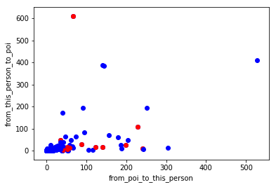

```python
for name in data_dict:
    plt.scatter(data_dict[name]['from_poi_to_this_person'],data_dict[name]['from_this_person_to_poi'],color = 'b')
    if data_dict[name]['poi']==1:
        plt.scatter(data_dict[name]['from_poi_to_this_person'],data_dict[name]['from_this_person_to_poi'],color = 'r')
plt.xlabel('from_poi_to_this_person')
plt.ylabel('from_this_person_to_poi')
plt.show()
```

从可视化中可以看出：嫌疑人发送和接收嫌疑人的邮件数量与非嫌疑人发送接收嫌疑人邮件的数量近似，离群值中大部分不是嫌疑人。因此这两个特征对找出嫌疑人并不能起到多少帮助，需要移除这两个噪音特征。

```python
features_list = ['salary','deferral_payments', 'total_payments', 'exercised_stock_options',\
                 'bonus', 'restricted_stock', 'shared_receipt_with_poi', 'restricted_stock_deferred',\
                 'total_stock_value', 'expenses', 'loan_advances','other',\
                 'director_fees', 'deferred_income', 'long_term_incentive']
```

所使用算法：pca_GaussianNB = Pipeline([('scaler',scaler),('pca', pca), ('GaussianNB', clf)])

Accuracy: 0.82927 Precision: 0.32907 Recall: 0.27000 F1: 0.29662 F2: 0.28005

在去除掉这两个特征后算法性能有所下降，继续筛选特征并进行性能测试。

# 创建2个新特征：fraction_from_poi和fraction_to_poi

```python
for name in data_dict:
    if data_dict[name]['from_poi_to_this_person']=='NaN':
        data_dict[name]['fraction_from_poi']=0
    if data_dict[name]['to_messages']=='NaN':
        data_dict[name]['fraction_from_poi']=0
    if data_dict[name]['from_this_person_to_poi']=='NaN':
        data_dict[name]['fraction_to_poi']=0
    if data_dict[name]['from_messages']=='NaN':
        data_dict[name]['fraction_to_poi']=0
    else:
        data_dict[name]['fraction_from_poi']=float((data_dict[name]['from_poi_to_this_person']))/float((data_dict[name]['to_messages']))
        data_dict[name]['fraction_to_poi']=float((data_dict[name]['from_this_person_to_poi']))/float((data_dict[name]['from_messages']))


pd.DataFrame(data_dict,index = ['fraction_from_poi','fraction_to_poi'])
```

|  | ALLEN PHILLIP K | BADUM JAMES P | BANNANTINE JAMES M | BAXTER JOHN C | BAY FRANKLIN R | BAZELIDES PHILIP J | BECK SALLY W | BELDEN TIMOTHY N | BELFER ROBERT | BERBERIAN DAVID | ... | WASAFF GEORGE | WESTFAHL RICHARD K | WHALEY DAVID A | WHALLEY LAWRENCE G | WHITE JR THOMAS E | WINOKUR JR. HERBERT S | WODRASKA JOHN | WROBEL BRUCE | YEAGER F SCOTT | YEAP SOON |
| --- | --- | --- | --- | --- | --- | --- | --- | --- | --- | --- | --- | --- | --- | --- | --- | --- | --- | --- | --- | --- | --- |
| fraction_from_poi | 0.016196 | 0 | 0.068905 | 0 | 0 | 0 | 0.019686 | 0.028532 | 0 | 0 | ... | 0.055000 | 0 | 0 | 0.030902 | 0 | 0 | 0 | 0 | 0 | 0 |
| fraction_to_poi | 0.029613 | 0 | 0.000000 | 0 | 0 | 0 | 0.088879 | 0.223140 | 0 | 0 | ... | 0.233333 | 0 | 0 | 0.043165 | 0 | 0 | 0 | 0 | 0 | 0 |

可视化新的特征：

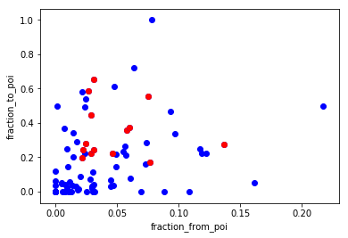

```python
for name in data_dict:
    plt.scatter(data_dict[name]['fraction_from_poi'],data_dict[name]['fraction_to_poi'],color = 'b')
    if data_dict[name]['poi']==1:
        plt.scatter(data_dict[name]['fraction_from_poi'],data_dict[name]['fraction_to_poi'],color = 'r')
plt.xlabel('fraction_from_poi')
plt.ylabel('fraction_to_poi')
plt.show()
```

在特征列表中加入新创建的特征：fraction_from_poi和fraction_to_poi

```python
features_list = ['salary','deferral_payments', 'total_payments', 'exercised_stock_options',\
                 'bonus', 'restricted_stock', 'shared_receipt_with_poi', 'restricted_stock_deferred',\
                 'total_stock_value', 'expenses', 'loan_advances','other',\
                 'director_fees', 'deferred_income', 'long_term_incentive','fraction_from_poi','fraction_to_poi']
```

所使用算法：pca_GaussianNB = Pipeline([('scaler',scaler),('pca', pca), ('GaussianNB', clf)])

Accuracy: 0.84467 Precision: 0.35552 Recall: 0.20300 F1: 0.25843 F2: 0.22205

使用新特征后算法性能有明显下降，因此在最终算法中会放弃使用新特征。

# 通过算法的属性找到特征重要性：

此时，在手动选择特征时出现了困难，打算采用特征选择器的属性来找到最佳特征：下面是没有经过删减的特征

```python
features_list = ['poi','salary','deferral_payments', 'total_payments', 'exercised_stock_options',\
                 'bonus', 'restricted_stock', 'restricted_stock_deferred','long_term_incentive',\
                 'total_stock_value', 'expenses', 'loan_advances','other','director_fees', 'deferred_income', 'shared_receipt_with_poi', \
                 'from_poi_to_this_person','to_messages', 'from_messages','from_this_person_to_poi']
```

使用2种方法来找到最佳特征：

采用SelectKBest()的scores_属性，找到最佳特征：

```python
[ 16.59687738   0.14015191   8.67593724  26.3129144   20.13246585
   9.11795651   0.07268335  10.9527158   25.24659416   9.81504841
   7.3499902    3.04227725   1.93697148  11.63314211   9.00763085
   2.87636243   1.62001438   0.15915062   2.37919262]
```

采用DecisionTreeClassifier()的feature_importances_属性，找到特征的权重分配：

```python
[ 0.0419128   0.13765438  0.09404991  0.          0.2189863   0.          0.
  0.          0.          0.13915329  0.          0.21840964  0.
  0.14983368  0.          0.          0.          0.          0.        ]
```

通过观察发现使用两款分类器的属性，得到的后4个邮件特征的权重都很低，因此推断邮件特征对于算法性能起到的作用并不大，因此决定删除这些邮件特征，只使用少数典型的财务特征。

```python
features_list = [salary','total_stock_value','total_payments','long_term_incentive','exercised_stock_options','bonus','deferred_income']
```

所使用算法：pca_GaussianNB = Pipeline([('scaler',scaler),('pca', pca), ('GaussianNB', clf)])

算法性能表现：Accuracy: 0.88000 Precision: 0.57429 Recall: 0.38650 F1: 0.46204 F2: 0.41355

在只使用典型财务特征时，算法表现出了非常优秀的性能，证明邮件特征和财务特征相比，财务特征更加具有显著性的含义。

# 适当缩放特征:

因为在特征中，有的值很高，有的值偏低，为了不被某一个特征主导权重，项目的算法使用了MinMaxScaler()特征缩放器。

# 选择算法：

在最终项目中，尝试了3中算法，分别是：朴素贝叶斯，支持向量机和决策树算法。

三种算法的性能比较：

第一种：朴素贝叶斯

```python
scaler = MinMaxScaler()
pca = PCA(n_components=5)
GaussianNB= GaussianNB()
clf = Pipeline([('scaler',scaler),('pca', pca), ('GaussianNB', GaussianNB)])
```

Accuracy: 0.88000 Precision: 0.57429 Recall: 0.38650 F1: 0.46204 F2: 0.41355

第二种：支持向量机

```python
scaler = MinMaxScaler()
pca = PCA(n_components=5)
svc = svm.SVC(kernel = 'rbf',C = 100)
clf = Pipeline([('scaler',scaler),('pca', pca), ('svc', svc)])
```

Accuracy: 0.86087 Precision: 0.38400 Recall: 0.07200 F1: 0.12126 F2: 0.08597

第三种：决策树

```python
scaler = MinMaxScaler()
pca = PCA(n_components=5)
DecisionTree = tree.DecisionTreeClassifier(min_samples_split=10)
clf = Pipeline([('scaler',scaler),('pca', pca), ('tree', DecisionTree)])
```

Accuracy: 0.81253 Precision: 0.27062 Recall: 0.23950 F1: 0.25411 F2: 0.24514

经过对比：在最终算法中使用了朴素贝叶斯算法

# 讨论参数调整的意义及其重要性：

参数调整的意义：参数调整可以让算法具有更优秀的性能，具备的更好的预测能力。

参数调整的重要性：在机器学习中参数调整通常是必不可少的步骤，因为对于不同的数据，算法需要重新适应以发挥最好的性能。

# 调整算法：

使用GridSearchCV调整参数：parameters = {'pca__n_components':(3,4,5,6)}

```python
from sklearn.preprocessing import MinMaxScaler
from sklearn.pipeline import Pipeline
from sklearn.decomposition import PCA
from sklearn.naive_bayes import GaussianNB
from sklearn.model_selection import GridSearchCV
scaler = MinMaxScaler()
pca = PCA()
GaussianNB = GaussianNB()
pipeline = Pipeline([('scaler',scaler),('pca', pca), ('GaussianNB', GaussianNB)])
parameters = {'pca__n_components':(3,4,5,6)}
clf = GridSearchCV(pipeline,parameters)
```

交叉验证得到的PCA最佳参数平均值为：average_pca_n_components: 3.579

因此在最终算法中：选择 n_components = 4 作为PCA的参数

算法性能如下：

Accuracy: 0.88000 Precision: 0.57429 Recall: 0.38650 F1: 0.46204 F2: 0.41355

如果使用决策树算法关于参数的调整策略：

min_samples_split参数的大小会改变决策面的形状，可能会把一部分点包含或者排除在决策面的另一面，如果参数值过小可能会出现过拟合的情况。

# 评估度量的使用：

由于数据集中POI与非POI的比例很不平衡，而Accuracy是对二者准确率的统一评估，因此在本项目中Accuracy并不是一个很合适的评估指标，仅作为参考指标。

主要评估指标：精确度Precision、召回率Recall。

参考指标：准确率Accuracy、以及F1分数、F2分数

项目任务背景下的测量对象：

项目的标签中有POI和非POI两种类型，Precision和Recall可以分别对这两种类型进行测量，在本项目中我们只使用Precision和Recall对POI的识别情况进行测量

经过1000次迭代后，我们统计出了计算Precision和Recall需要用到的3个加总值：false_negatives（FN）、true_positives（TP）、false_positives（FP）

TP含义：是POI并且判断正确的数量。 FP含义：不是POI被误报为POI的数量。 FN含义：是POI但是没有查出来被报成非POI的数量。

Precision = TP/(TP+FP)含义：被识别为POI的数据中有多少是真正的POI，这就是精确度的计算。

Recall = TP/(TP+FN)含义：全部POI中有多少被识别了出来，或者说，被识别出来的POI占全部POI的比例，这就是召回率的计算。

# 讨论验证及其重要性：

什么是验证：

通常拿到一个数据集后，我们需要将样本分为训练集和测试集两部分，训练集用来训练机器学习模型，而测试集用来验证训练效果，也就是验证算法的的性能。

验证时可能会出现的错误：

训练集和测试集是需要分离的，如果用了全部数据集做训练，那么再拿出全部数据的一部分数据做验证，这样的验证就没有意义了，因为这部分数据已经学习过了，再验证肯定会接近100%正确，所以这种错误是需要避免的。验证一定是去验证模型没有学习过的数据。

验证的重要性：

在使用训练集对机器学习模型进行过训练后，模型就具有了一定程度的预测独立同分布未知数据的能力，而验证就是用来检验模型学习效果的最好方法。也就是说让模型学习一部分数据，然后通过已经学到的经验去预测未知数据，而学习情况的好坏则需要通过对测试集的验证来辨别，如果学的效果不好，可以通过调参来进一步学习，直到满意为止。

# 验证策略：

因为数据的不平衡性，我们会选用Stratified Shuffle Split的方式将数据分为验证集和测试集，而使用Stratified Shuffle Split随机分层抽样交叉验证的好处是，在每次抽样的时候，训练集和测试集都可以分配到相同比例的POI和非POI，不会因为POI数量过少，而导致测试集分配不到POI的情况发生，影响评估效果。

最终算法使用分层随机抽样交叉验证：StratifiedShuffleSplit(n_splits=1000, test_size=0.1, random_state=42)

n_splits=1000：交叉验证经过1000次迭代，汇总关于POI的相关数据：true_negatives、false_negatives、true_positives、false_positives

test_size=0.1：每次迭代，测试集被随机分配到10%的样本，并且保持每次样本中POI和非POI的比例相同。

random_state=42：可以让使每次运行程序得出的评估结果一致。

# 算法性能：

使用 tester.py 评估性能：Accuracy: 0.88000 Precision: 0.57429 Recall: 0.38650 F1: 0.46204 F2: 0.41355

Accuracy: 0.88：说明模型对整体数据的预测准确率还是很高的，这其中包含对POI和非POI的预测准确率。

Precision: 0.57：说明在找出的POI中有57%是真POI，有43%是误报的，也就是把非POI标记成了POI。

Recall: 0.38：说明在全部POI中，只有38%被机器学习模型标记了出来，而剩下的62%都被没有找出来被漏报了。

# 项目源代码：

```python
#=========================================================================================#
#                                   导入基本库函数                                        #
#=========================================================================================#
import numpy as np
import sys
sys.path.append("final_project/")
from feature_format import featureFormat, targetFeatureSplit
from tester import test_classifier,dump_classifier_and_data
import pickle
import pandas as pd
#=========================================================================================#
#                        选择特征同时去掉数据集中的异常值                                 #
#=========================================================================================#


features_list = ['poi','salary',
                'total_stock_value','total_payments','long_term_incentive',
                'exercised_stock_options','bonus','deferred_income']
#features_list = ['poi','salary','deferral_payments', 'total_payments', 'exercised_stock_options',\
                 #'bonus', 'restricted_stock', 'restricted_stock_deferred','long_term_incentive',\
                 #'total_stock_value', 'expenses', 'loan_advances','other','director_fees', 'deferred_income', 'shared_receipt_with_poi', \
                 #'from_poi_to_this_person','to_messages', 'from_messages','from_this_person_to_poi']
#features_list = ['poi','salary','deferral_payments', 'total_payments', 'exercised_stock_options',\
                 #'bonus', 'restricted_stock', 'shared_receipt_with_poi', 'restricted_stock_deferred',\
                 #'total_stock_value', 'expenses', 'loan_advances','other', 'from_this_person_to_poi', \
                 #'director_fees', 'deferred_income', 'long_term_incentive', 'from_poi_to_this_person']
#features_list = ['poi','salary','deferral_payments', 'total_payments', 'exercised_stock_options',\
                 #'bonus', 'restricted_stock', 'shared_receipt_with_poi', 'restricted_stock_deferred',\
                 #'total_stock_value', 'expenses', 'loan_advances','other',\
                 #'director_fees', 'deferred_income', 'long_term_incentive']
#features_list = ['poi','salary','deferral_payments', 'total_payments', 'exercised_stock_options',\
                 #'bonus', 'restricted_stock', 'shared_receipt_with_poi', 'restricted_stock_deferred',\
                 #'total_stock_value', 'expenses', 'loan_advances','other',\
                 #'director_fees', 'deferred_income', 'long_term_incentive','fraction_from_poi','fraction_to_poi']

with open("final_project/final_project_dataset.pkl","rb") as data_file:
    data_dict = pickle.load(data_file)


outliers =['LOCKHART EUGENE E','TOTAL']
for name in outliers:
    data_dict.pop(name)




#=========================================================================================#
#                    创建2个新的特征fraction_from_poi和fraction_to_poi                    #
#=========================================================================================#


for name in data_dict:
    if data_dict[name]['from_poi_to_this_person']=='NaN':
        data_dict[name]['fraction_from_poi']=0
    if data_dict[name]['to_messages']=='NaN':
        data_dict[name]['fraction_from_poi']=0
    if data_dict[name]['from_this_person_to_poi']=='NaN':
        data_dict[name]['fraction_to_poi']=0
    if data_dict[name]['from_messages']=='NaN':
        data_dict[name]['fraction_to_poi']=0
    else:
        data_dict[name]['fraction_from_poi']=float((data_dict[name]['from_poi_to_this_person']))/float((data_dict[name]['to_messages']))
        data_dict[name]['fraction_to_poi']=float((data_dict[name]['from_this_person_to_poi']))/float((data_dict[name]['from_messages']))

my_dataset = data_dict
#=========================================================================================#
#                                 把字典转化成数组                                        #
#=========================================================================================#

data = featureFormat(my_dataset, features_list, sort_keys = True)

#=========================================================================================#
#                               把特征和标签分开                                          #
#=========================================================================================#

labels , features = targetFeatureSplit( data )

#=========================================================================================#
#                用Pipeline把：特征缩放、PCA主成分提取、分类器封装到一起                  #
#=========================================================================================#
from sklearn.preprocessing import MinMaxScaler
from sklearn.pipeline import Pipeline
from sklearn.decomposition import PCA
from sklearn.naive_bayes import GaussianNB
from sklearn import svm
from sklearn import tree
from sklearn.feature_selection import SelectKBest,f_classif,chi2
from sklearn.model_selection import GridSearchCV

#clf  = tree.DecisionTreeClassifier(min_samples_split=10)

scaler = MinMaxScaler()
pca = PCA(n_components=4)
GaussianNB = GaussianNB()
clf = Pipeline([('scaler',scaler),('pca', pca), ('GaussianNB', GaussianNB)])


#scaler = MinMaxScaler()
#pca = PCA()
#GaussianNB = GaussianNB()
#pipeline = Pipeline([('scaler',scaler),('pca', pca), ('GaussianNB', GaussianNB)])
#parameters = {'pca__n_components':(3,4,5,6)}
#clf = GridSearchCV(pipeline,parameters)

#scaler = MinMaxScaler()
#kbest = SelectKBest(f_classif,k=5)
#GaussianNB = GaussianNB()
#clf = Pipeline([('kbest', kbest), ('GaussianNB', GaussianNB)])


#scaler = MinMaxScaler()
#kbest = SelectKBest(f_classif,k=5)
#GaussianNB = GaussianNB()
#clf = Pipeline([('scaler',scaler),('kbest', kbest), ('GaussianNB', GaussianNB)])

#scaler = MinMaxScaler()
#pca = PCA(n_components=5)
#svc = svm.SVC(kernel = 'rbf',C = 100)
#clf = Pipeline([('scaler',scaler),('pca', pca), ('svc', svc)])

#scaler = MinMaxScaler()
#pca = PCA(n_components=5)
#DecisionTree = tree.DecisionTreeClassifier(min_samples_split=10)
#clf = Pipeline([('scaler',scaler),('pca', pca), ('tree', DecisionTree)])


#=========================================================================================#
#                            分层随机抽样交叉验证                                         #
#=========================================================================================#
#from sklearn.cross_validation import StratifiedShuffleSplit#旧版本
#sss = StratifiedShuffleSplit(labels, 1000, test_size = 0.1,random_state=42)
#for train,test in sss:
true_negatives = 0
false_negatives = 0
true_positives = 0
false_positives = 0
#best_prameters = []
from sklearn.model_selection import StratifiedShuffleSplit#新版本
sss = StratifiedShuffleSplit(n_splits=1000, test_size=0.1, random_state=42)
for train,test in sss.split(features,labels):#features
    features_train = [features[i] for i in train]#features
    labels_train = [labels[i]for i in train]
    features_test = [features[i]for i in test]#features
    labels_test = [labels[i]for i in test]

    clf.fit(features_train,labels_train)

    #a = clf.best_params_
    #best_prameters.append(a['pca__n_components'])

    #print(clf.feature_importances_)
    #print(kbest.scores_)
    predictions =  clf.predict(features_test)
    for prediction, truth in zip(predictions, labels_test):
        if prediction == 0 and truth == 0:
            true_negatives += 1
        elif prediction == 0 and truth == 1:
            false_negatives += 1
        elif prediction == 1 and truth == 0:
            false_positives += 1
        elif prediction == 1 and truth == 1:
            true_positives += 1
        else:
            print ("Warning: Found a predicted label not == 0 or 1.")
            print ("All predictions should take value 0 or 1.")
            print ("Evaluating performance for processed predictions:")
            break
PERF_FORMAT_STRING = "\tAccuracy: {:>0.5f}\tPrecision: {:>0.5f}\tRecall: {:>0.5f}\tF1: {:>0.5f}\tF2: {:>0.5f}"
RESULTS_FORMAT_STRING = "\tTotal predictions: {}\tTrue positives: {}\tFalse positives: {}\tFalse negatives: {}\tTrue negatives: {}"
#print('average_pca_n_components:',np.array(best_prameters).mean())
#print('\n')
try:
    total_predictions = true_negatives + false_negatives + false_positives + true_positives
    accuracy = 1.0*(true_positives + true_negatives)/total_predictions
    precision = 1.0*true_positives/(true_positives+false_positives)
    recall = 1.0*true_positives/(true_positives+false_negatives)
    f1 = 2.0 * true_positives/(2*true_positives + false_positives+false_negatives)
    f2 = (1+2.0*2.0) * precision*recall/(4*precision + recall)
    print ('my_predict:','\n')
    print (clf)
    print (PERF_FORMAT_STRING.format(accuracy, precision, recall, f1, f2))
    print (RESULTS_FORMAT_STRING.format(total_predictions, true_positives, false_positives, false_negatives, true_negatives))
    print ("")
    print ('tester.py:','\n')
except:
    print ("Got a divide by zero when trying out:", clf)#
    print ("Precision or recall may be undefined due to a lack of true positive predicitons.")

#=========================================================================================#
#                        存储分类器，数据集，和特征列表                                   #
#=========================================================================================#

dump_classifier_and_data(clf, my_dataset, features_list)


#=========================================================================================#
#            算法性能：当使用 tester.py 评估性能时，精确度、召回率均至少为 0.3            #
#=========================================================================================#

test_classifier(clf, my_dataset, features_list, folds = 1000)
```

```
my_predict:

Pipeline(memory=None,
     steps=[('scaler', MinMaxScaler(copy=True, feature_range=(0, 1))), ('pca', PCA(copy=True, iterated_power='auto', n_components=4, random_state=None,
  svd_solver='auto', tol=0.0, whiten=False)), ('GaussianNB', GaussianNB(priors=None))])
	Accuracy: 0.88000	Precision: 0.57429	Recall: 0.38650	F1: 0.46204	F2: 0.41355
	Total predictions: 15000	True positives: 773	False positives: 573	False negatives: 1227	True negatives: 12427

tester.py:

Pipeline(memory=None,
     steps=[('scaler', MinMaxScaler(copy=True, feature_range=(0, 1))), ('pca', PCA(copy=True, iterated_power='auto', n_components=4, random_state=None,
  svd_solver='auto', tol=0.0, whiten=False)), ('GaussianNB', GaussianNB(priors=None))])
	Accuracy: 0.88000	Precision: 0.57429	Recall: 0.38650	F1: 0.46204	F2: 0.41355
	Total predictions: 15000	True positives:  773	False positives:  573	False negatives: 1227	True negatives: 12427
```